# Trabalho de Inteligência Artificial

#### Verifique como os dados do preço se distribuem (Dica: Crie um histograma)

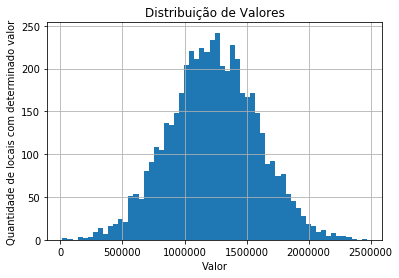

```python
#Confirmar atraves de uma visualização como os dados estão dispostos atraves de uma media de valores "Preços"
# histograma
df.Price.hist(bins = 60)
plt.xlabel("Valor")
plt.ylabel("Quantidade de locais com determinado valor")
plt.title("Distribuição de Valores")
plt.show()
```

```python
# Verificando o tipo de corelação que existe entre as variaveis e o nivel de implicação de casualidade
def plot_corr(df, size=20):
    corr = df.corr()
    fig, ax = plt.subplots(figsize = (size, size))
    ax.matshow(corr)
    plt.xticks(range(len(corr.columns)), corr.columns)
    plt.yticks(range(len(corr.columns)), corr.columns)
```

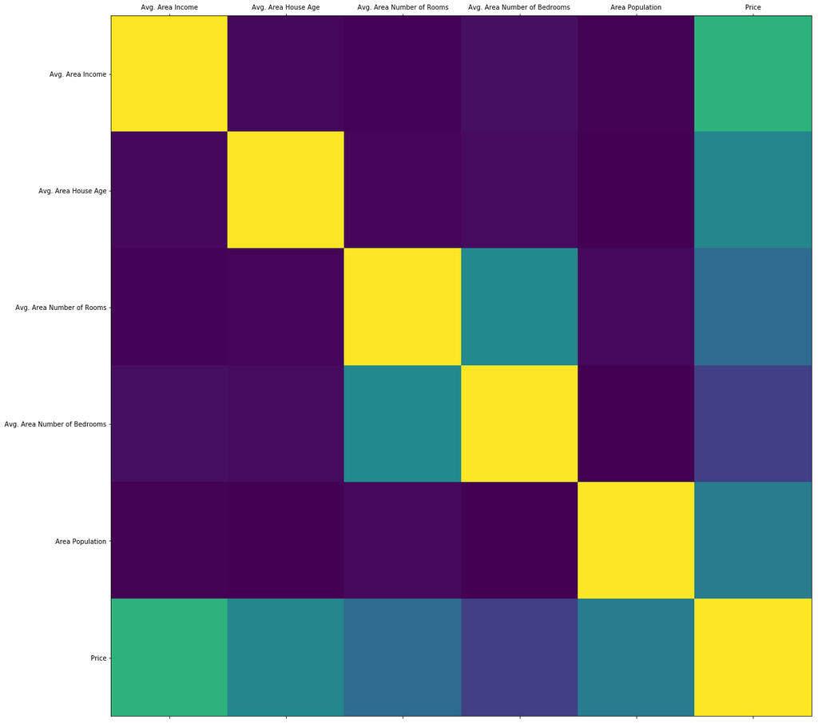

```python
#print do grafico gerado
plot_corr(df)
```

#### Utilize a correlação para identificar o comportamento das variáveis (Dica: Verifique a função corr()). Quais as descobertas que você conseguiu fazer a partir da análise da correlação?

```python
#Uma correlação entre os valores em pares de colunas onde os valores eram excluidos valores NA ou seja valores nulos
#Atraves do comando pode-se encontrar a correlação em pares de todas as colunas no quadro de dados imprimido da tela
#Onde
#valores eram excluidos valores NA ou seja valores nulos são excluídos automaticamente.
#Para qualquer coluna de tipo de dados não numérico no quadro de dados, ela é ignorada.
df.corr()
```

|  | Avg. Area Income | Avg. Area House Age | Avg. Area Number of Rooms | Avg. Area Number of Bedrooms | Area Population | Price |
| --- | --- | --- | --- | --- | --- | --- |
| Avg. Area Income | 1.000000 | -0.002007 | -0.011032 | 0.019788 | -0.016234 | 0.639734 |
| Avg. Area House Age | -0.002007 | 1.000000 | -0.009428 | 0.006149 | -0.018743 | 0.452543 |
| Avg. Area Number of Rooms | -0.011032 | -0.009428 | 1.000000 | 0.462695 | 0.002040 | 0.335664 |
| Avg. Area Number of Bedrooms | 0.019788 | 0.006149 | 0.462695 | 1.000000 | -0.022168 | 0.171071 |
| Area Population | -0.016234 | -0.018743 | 0.002040 | -0.022168 | 1.000000 | 0.408556 |
| Price | 0.639734 | 0.452543 | 0.335664 | 0.171071 | 0.408556 | 1.000000 |

#### Se você fosse trabalhar com um modelo linear univariado, qual seria a variável independente que você escolheria como parte do modelo?

```python
#Resposta:
# Fazendo uma observação ao qual poderia permitir uma análise de cada variável separadamente
# e refletindo sobre como funciona o sistema economico e usando de conhecimentos sobre
# os sistema de logistica de imoveis ao qual afetariam os métodos de estatística ao qual determinnam as  variáveis
# seria escolhido sendo X_treino o tamanho de casas o Y_treino o preço
# acredito ser mais relevante na relação
# porem como não existe um tamanho para a casa, mas apenas uma relação de Avg. Area Income	Avg. Area House Age
# que eu não entendi se seria Avg. Area Income "por media do valor do tamanho da casa",
# usaria então Area media do numero de quartos.
```

## Criando um modelo de regressão linear

- Como soluções candidatas você pode considerar os seguintes modelos:
  - [Gradiente descendente estocástico - SGDRegressor](https://scikit-learn.org/stable/modules/generated/sklearn.linear_model.SGDRegressor.html#sklearn.linear_model.SGDRegressor)
  - [Regressão linear](https://scikit-learn.org/stable/modules/generated/sklearn.linear_model.LinearRegression.html)

### Regressão univariada

Crie um modelo de regressão univariada com base na variávei independente escolhida anteriormente.

```python
#import tensorflow as tf
#pip install -q tensorflow
# Não consegui importar
```

```python
#tratando valores missing ------- inicio do tratamento
# importando preprocessador do pactoe para então dizer os valores faltantes para então serem substituidos
import sklearn as sk
```

```python
from sklearn.model_selection import train_test_split
```

```python
from sklearn.naive_bayes import GaussianNB
```

```python
from sklearn import metrics
```

```python
from sklearn.ensemble import RandomForestClassifier
```

```python
from sklearn.linear_model import LogisticRegression
```

```python
import sklearn
print (sklearn.__version__)
#Por causa desse problema de versão
```

```
0.19.1
```

```python
import numpy as np
#from sklearn.impute import SimpleImputer <- codigo abaixo substitui a forma de importação
from sklearn.preprocessing import Imputer
```

```python
#Fim das importações
```

```python
# Criando objeto para substituição dos valores que faltam pela media, eles serao posterirmente inseridos dessa maneira
# nos dados de treino
preenche = Imputer(missing_values = 0, strategy = "mean")
```

```python
# Variável a ser prevista
atrib_prev = ['Avg. Area Number of Rooms']
```

```python
# Seleção de variáveis preditoras (Feature Selection)
atributos = ['Avg. Area Income', 'Avg. Area House Age', 'Avg. Area Number of Rooms', 'Avg. Area Number of Bedrooms', 'Area Population', 'Address']
```

```python
# Criando objetos
X = df[atributos].values
Y = df[atrib_prev].values
```

```python
#Print dos dados dentro armazenados
print(X)
```

```
[[79545.45857431678 5.682861321615587 7.009188142792237 4.09
  23086.800502686456
  '208 Michael Ferry Apt. 674\nLaurabury, NE 37010-5101']
 [79248.64245482568 6.0028998082752425 6.730821019094919 3.09
  40173.07217364482
  '188 Johnson Views Suite 079\nLake Kathleen, CA 48958']
 [61287.067178656784 5.865889840310001 8.512727430375099 5.13
  36882.15939970458 '9127 Elizabeth Stravenue\nDanieltown, WI 06482-3489']
 ...
 [63390.68688550463 7.250590614779546 4.805080980291155 2.13
  33266.145489652175
  '4215 Tracy Garden Suite 076\nJoshualand, VA 01707-9165']
 [68001.33123508695 5.534388416220344 7.130143864349472 5.44
  42625.62015585088 'USS Wallace\nFPO AE 73316']
 [65510.581803666224 5.992305307333977 6.792336104424982 4.07
  46501.28380314165
  '37778 George Ridges Apt. 509\nEast Holly, NV 29290-3595']]
```

```python
#Print dos dados dentro armazenados
print(Y)
```

```
[[7.00918814]
 [6.73082102]
 [8.51272743]
 ...
 [4.80508098]
 [7.13014386]
 [6.7923361 ]]
```

```python
#Fazendo um split, uma divisão de dados para serem treinados
```

```python
# Definindo a taxa de split em 30% e 70% como explicados em sala de aula e debatidos
split_test_size = 0.30
```

```python
# Criando um modelo de dados para realizar o treino e de teste
X_treino, X_teste, Y_treino, Y_teste = train_test_split(X, Y, test_size=0.30, random_state=101)
```

```python
# Imprimindo os resultados de como os dados serão treinados e testados
print("{0:0.2f}% nos dados de treino".format((len(X_treino)/len(df.index)) * 100))
print("{0:0.2f}% nos dados de teste".format((len(X_teste)/len(df.index)) * 100))
```

```
70.00% nos dados de treino
30.00% nos dados de teste
```

```python
X_treino
```

```
array([[86690.87330097138, 6.2599009337225535, 6.676265370468488, 3.23,
        42589.62439070174,
        '7459 Jasmine Brook Suite 688\nHallmouth, ME 52705-6457'],
       [59866.94770020468, 5.8703298334712, 5.899076341909404, 4.16,
        32064.597156277174,
        '179 Larsen Oval\nNew Matthew, DC 48602-6064'],
       [74372.13845247941, 6.562379590475677, 8.184510518059634, 6.35,
        34321.96015488425,
        '111 Wilson Cape Suite 484\nHernandezton, VI 53808'],
       ...,
       [55621.89910395666, 3.7359417914541786, 6.868290757394464, 2.3,
        63184.613147230324,
        '704 Davis Valleys Suite 264\nCollinstown, DE 61159'],
       [63044.46009609616, 5.935261391452768, 5.913453614518467, 4.1,
        32725.27954357492,
        '392 Jonathan Divide\nDonnaland, ND 01024-1699'],
       [75078.79151567799, 7.644778598059883, 8.440726153497362, 4.33,
        56148.44932156281,
        '304 Obrien Village Suite 750\nWest Maureen, AS 63430']],
      dtype=object)
```

```python
#Confirmação de que não existem valores missing dentro do dataframe que esta sendo desenvolvido e treinado
print("# Linhas no dataframe {0}".format(len(df)))
print("# Linhas missing Avg. Area Income: {0}".format(len(df.loc[df['Avg. Area Income'] == 0])))
print("# Linhas missing Avg. Area House Age: {0}".format(len(df.loc[df['Avg. Area House Age'] == 0])))
print("# Linhas missing Avg. Area Number of Rooms: {0}".format(len(df.loc[df['Avg. Area Number of Rooms'] == 0])))
print("# Linhas missing Avg. Area Number of Bedrooms: {0}".format(len(df.loc[df['Avg. Area Number of Bedrooms'] == 0])))
print("# Linhas missing Area Population: {0}".format(len(df.loc[df['Area Population'] == 0])))
print("# Linhas missing Price: {0}".format(len(df.loc[df['Price'] == 0])))
print("# Linhas missing Address: {0}".format(len(df.loc[df['Address'] == 0])))
```

```
# Linhas no dataframe 5000
# Linhas missing Avg. Area Income: 0
# Linhas missing Avg. Area House Age: 0
# Linhas missing Avg. Area Number of Rooms: 0
# Linhas missing Avg. Area Number of Bedrooms: 0
# Linhas missing Area Population: 0
# Linhas missing Price: 0
# Linhas missing Address: 0
```

```python
df.head(5)
```

|  | Avg. Area Income | Avg. Area House Age | Avg. Area Number of Rooms | Avg. Area Number of Bedrooms | Area Population | Price | Address |
| --- | --- | --- | --- | --- | --- | --- | --- |
| 0 | 79545.458574 | 5.682861 | 7.009188 | 4.09 | 23086.800503 | 1.059034e+06 | 208 Michael Ferry Apt. 674\nLaurabury, NE 3701... |
| 1 | 79248.642455 | 6.002900 | 6.730821 | 3.09 | 40173.072174 | 1.505891e+06 | 188 Johnson Views Suite 079\nLake Kathleen, CA... |
| 2 | 61287.067179 | 5.865890 | 8.512727 | 5.13 | 36882.159400 | 1.058988e+06 | 9127 Elizabeth Stravenue\nDanieltown, WI 06482... |
| 3 | 63345.240046 | 7.188236 | 5.586729 | 3.26 | 34310.242831 | 1.260617e+06 | USS Barnett\nFPO AP 44820 |
| 4 | 59982.197226 | 5.040555 | 7.839388 | 4.23 | 26354.109472 | 6.309435e+05 | USNS Raymond\nFPO AE 09386 |

```python
#removendo a coluna apenas comentada porque quando ja removida da erro
#removendo o endereço por ser um tipo de dado do tipo string que causara problemas excessivos para ser convertido para tipos
#inteiros!
#Considerado variaveis mais importantes: ---->
# ->>> Renda do lugar, Idade do Imovel, Numero de Quartos, Numero de banheiros, População da Area, Preco do mesmo
df.drop(['Address'],axis=1,inplace=True)
```

```python
df.head(5)
```

|  | Avg. Area Income | Avg. Area House Age | Avg. Area Number of Rooms | Avg. Area Number of Bedrooms | Area Population | Price |
| --- | --- | --- | --- | --- | --- | --- |
| 0 | 79545.458574 | 5.682861 | 7.009188 | 4.09 | 23086.800503 | 1.059034e+06 |
| 1 | 79248.642455 | 6.002900 | 6.730821 | 3.09 | 40173.072174 | 1.505891e+06 |
| 2 | 61287.067179 | 5.865890 | 8.512727 | 5.13 | 36882.159400 | 1.058988e+06 |
| 3 | 63345.240046 | 7.188236 | 5.586729 | 3.26 | 34310.242831 | 1.260617e+06 |
| 4 | 59982.197226 | 5.040555 | 7.839388 | 4.23 | 26354.109472 | 6.309435e+05 |

```python
from sklearn.model_selection import train_test_split
```

```python
#verificando conjunto total de dados
df
```

|  | Avg. Area Income | Avg. Area House Age | Avg. Area Number of Rooms | Avg. Area Number of Bedrooms | Area Population | Price |
| --- | --- | --- | --- | --- | --- | --- |
| 0 | 79545.458574 | 5.682861 | 7.009188 | 4.09 | 23086.800503 | 1.059034e+06 |
| 1 | 79248.642455 | 6.002900 | 6.730821 | 3.09 | 40173.072174 | 1.505891e+06 |
| 2 | 61287.067179 | 5.865890 | 8.512727 | 5.13 | 36882.159400 | 1.058988e+06 |
| 3 | 63345.240046 | 7.188236 | 5.586729 | 3.26 | 34310.242831 | 1.260617e+06 |
| 4 | 59982.197226 | 5.040555 | 7.839388 | 4.23 | 26354.109472 | 6.309435e+05 |
| 5 | 80175.754159 | 4.988408 | 6.104512 | 4.04 | 26748.428425 | 1.068138e+06 |
| 6 | 64698.463428 | 6.025336 | 8.147760 | 3.41 | 60828.249085 | 1.502056e+06 |
| 7 | 78394.339278 | 6.989780 | 6.620478 | 2.42 | 36516.358972 | 1.573937e+06 |
| 8 | 59927.660813 | 5.362126 | 6.393121 | 2.30 | 29387.396003 | 7.988695e+05 |
| 9 | 81885.927184 | 4.423672 | 8.167688 | 6.10 | 40149.965749 | 1.545155e+06 |
| 10 | 80527.472083 | 8.093513 | 5.042747 | 4.10 | 47224.359840 | 1.707046e+06 |
| 11 | 50593.695497 | 4.496513 | 7.467627 | 4.49 | 34343.991886 | 6.637324e+05 |
| 12 | 39033.809237 | 7.671755 | 7.250029 | 3.10 | 39220.361467 | 1.042814e+06 |
| 13 | 73163.663441 | 6.919535 | 5.993188 | 2.27 | 32326.123139 | 1.291332e+06 |
| 14 | 69391.380184 | 5.344776 | 8.406418 | 4.37 | 35521.294033 | 1.402818e+06 |
| 15 | 73091.866746 | 5.443156 | 8.517513 | 4.01 | 23929.524053 | 1.306675e+06 |
| 16 | 79706.963058 | 5.067890 | 8.219771 | 3.12 | 39717.813576 | 1.556787e+06 |
| 17 | 61929.077018 | 4.788550 | 5.097010 | 4.30 | 24595.901498 | 5.284852e+05 |
| 18 | 63508.194299 | 5.947165 | 7.187774 | 5.12 | 35719.653052 | 1.019426e+06 |
| 19 | 62085.276403 | 5.739411 | 7.091808 | 5.49 | 44922.106702 | 1.030591e+06 |
| 20 | 86294.999089 | 6.627457 | 8.011898 | 4.07 | 47560.775336 | 2.146925e+06 |
| 21 | 60835.089979 | 5.551222 | 6.517175 | 2.10 | 45574.741662 | 9.292476e+05 |
| 22 | 64490.650267 | 4.210323 | 5.478088 | 4.31 | 40358.960106 | 7.188872e+05 |
| 23 | 60697.351539 | 6.170484 | 7.150537 | 6.34 | 28140.967088 | 7.439998e+05 |
| 24 | 59748.855487 | 5.339340 | 7.748682 | 4.23 | 27809.986544 | 8.957371e+05 |
| 25 | 56974.476539 | 8.287562 | 7.312880 | 4.33 | 40694.869513 | 1.453975e+06 |
| 26 | 82173.626076 | 4.018525 | 6.992699 | 2.03 | 38853.918066 | 1.125693e+06 |
| 27 | 64626.880978 | 5.443360 | 6.988754 | 4.00 | 27784.742280 | 9.754295e+05 |
| 28 | 90499.057451 | 6.384359 | 4.242191 | 3.04 | 33970.164990 | 1.240764e+06 |
| 29 | 59323.792100 | 6.977828 | 8.273697 | 4.07 | 37520.657732 | 1.577018e+06 |
| ... | ... | ... | ... | ... | ... | ... |
| 4970 | 55980.204807 | 7.014510 | 5.458789 | 2.11 | 43968.687046 | 1.120943e+06 |
| 4971 | 73491.134427 | 5.784430 | 4.425959 | 3.37 | 30800.541060 | 1.111307e+06 |
| 4972 | 83695.272383 | 7.643507 | 7.127219 | 5.05 | 33113.759057 | 1.736402e+06 |
| 4973 | 78743.759274 | 6.583685 | 6.595683 | 4.07 | 24381.144540 | 1.340770e+06 |
| 4974 | 70720.296463 | 6.411801 | 5.048128 | 3.01 | 19114.019253 | 8.013486e+05 |
| 4975 | 54037.580879 | 8.471765 | 6.966072 | 3.27 | 28696.170856 | 1.324382e+06 |
| 4976 | 75046.313791 | 5.351169 | 7.797825 | 5.23 | 34107.888619 | 1.340344e+06 |
| 4977 | 75980.438843 | 6.583105 | 5.914892 | 3.23 | 40394.593489 | 1.518478e+06 |
| 4978 | 80393.339500 | 8.899713 | 5.652974 | 4.04 | 39547.932489 | 1.910585e+06 |
| 4979 | 82224.695006 | 5.434087 | 8.375708 | 3.12 | 57166.867510 | 1.823498e+06 |
| 4980 | 75664.024482 | 5.789203 | 6.415312 | 2.02 | 54724.251275 | 1.406865e+06 |
| 4981 | 71663.871293 | 6.150745 | 7.311907 | 6.33 | 24109.778060 | 1.203850e+06 |
| 4982 | 58800.908770 | 5.976507 | 7.304051 | 6.43 | 37426.709745 | 1.020096e+06 |
| 4983 | 69655.183954 | 7.721100 | 6.077795 | 4.29 | 32902.355584 | 1.194357e+06 |
| 4984 | 62623.359828 | 5.071624 | 6.771015 | 3.33 | 50985.971202 | 1.211900e+06 |
| 4985 | 75117.042949 | 6.036275 | 6.538111 | 2.22 | 43976.031060 | 1.378938e+06 |
| 4986 | 71060.406015 | 5.718839 | 7.222730 | 4.34 | 34814.585591 | 1.260241e+06 |
| 4987 | 65729.222330 | 6.237787 | 6.860475 | 3.12 | 25573.854289 | 1.197073e+06 |
| 4988 | 67637.840665 | 7.056673 | 5.774409 | 3.05 | 43846.531340 | 1.275143e+06 |
| 4989 | 47965.406896 | 5.694638 | 7.363327 | 5.40 | 46071.947337 | 8.852050e+05 |
| 4990 | 52723.876555 | 5.452237 | 8.124571 | 6.39 | 14802.088438 | 4.795006e+05 |
| 4991 | 74102.191890 | 5.657841 | 7.683993 | 3.13 | 24041.270592 | 1.263721e+06 |
| 4992 | 87499.125743 | 6.403473 | 4.836091 | 4.02 | 40815.199679 | 1.568701e+06 |
| 4993 | 69639.140896 | 5.007510 | 7.778375 | 6.05 | 54056.128430 | 1.381831e+06 |
| 4994 | 73060.846226 | 5.293682 | 6.312253 | 4.16 | 22695.695480 | 9.053549e+05 |
| 4995 | 60567.944140 | 7.830362 | 6.137356 | 3.46 | 22837.361035 | 1.060194e+06 |
| 4996 | 78491.275435 | 6.999135 | 6.576763 | 4.02 | 25616.115489 | 1.482618e+06 |
| 4997 | 63390.686886 | 7.250591 | 4.805081 | 2.13 | 33266.145490 | 1.030730e+06 |
| 4998 | 68001.331235 | 5.534388 | 7.130144 | 5.44 | 42625.620156 | 1.198657e+06 |
| 4999 | 65510.581804 | 5.992305 | 6.792336 | 4.07 | 46501.283803 | 1.298950e+06 |

5000 rows × 6 columns

```python
#PREPARAÇÃO DE DADOS CONCLUIDA!!!!!!!!!!!!! TODOS OS DADOS E AS FORMAS DOS DADOS FORAM CONFERIDOS EM SEUS ESTADOS
```